# 6315305_assignment_prediction_model

**However,regression coefficient race.ethnicities B,C and D do not reach statistical** **significance. Same applies for the regression coefficient parental.level.of.education** **for the education levels of: bachelor’s degree,some college,master’s degree** **high school.**

**On the contrast regression coefficient parental.level.of.education** **some high school is associated with a decrease of 2.4 points on math.score** **against asscociate’s degree.**

**The regression coefficient Lunch is associated with an increase of 2.8 points** **on math.score against free/reduced.The regression coefficient Reading.score is** **associated with an increase of 3.7 points on math.score.**

**The regression coefficient writing.score is associated** **with an increas of 0.35 on math.score. The regression coefficient test.preparation** **none is associated with an increase of 0.67 against completed preparation.**

```r
y_pred2 <- predict(model2,newdata = p.student_test)
```

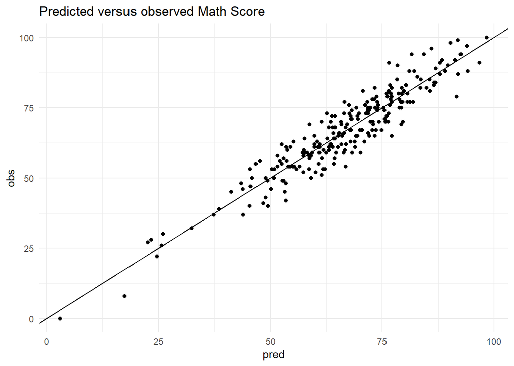

```r
tibble(pred = y_pred2,
       obs  = p.student_test$math.score) %>%
  ggplot(aes(x = pred, y = obs)) +
  geom_point() +
  theme_minimal() +
  geom_abline(slope = 1)+
  labs(title = "Predicted versus observed Math Score")
```

```r
#95% confidence interval
prediction1 <- predict(model2, p.student_test, interval="confidence", level = 0.95)
```

**Residuals plot**

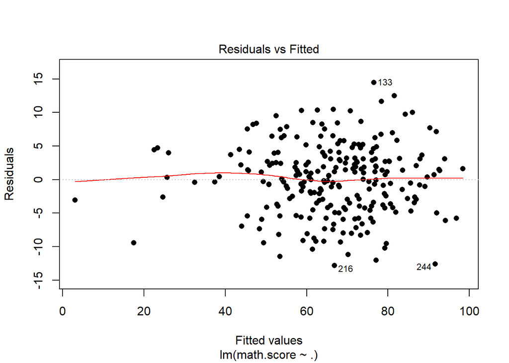

```r
plot(model2, pch=16, which=1)
```

**This residual plot is constructed from the multiple linear regression “model2”.** **The red line is a smooth fit to the residuals.** **From the examination of the plot, the line is a smooth fit to the residuals.** **Also, from the histogram on the residuals we can see that they form** **normal distribution.**

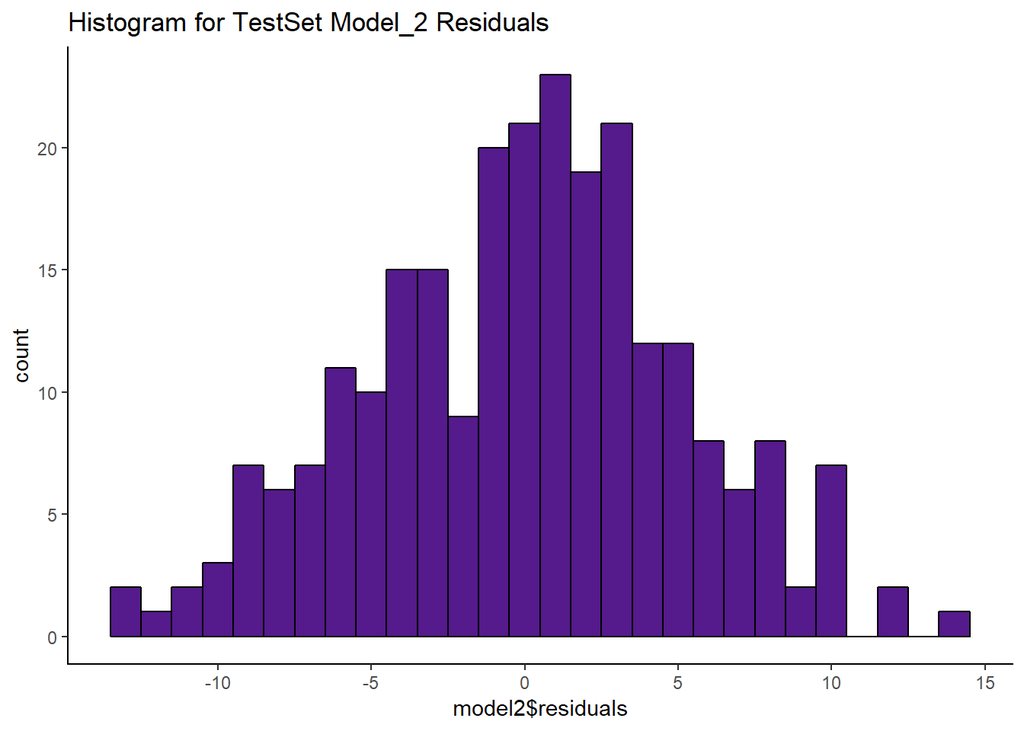

```r
ggplot(data=p.student_test, aes(model2$residuals)) +
    geom_histogram(binwidth = 1, color = "black", fill = "purple4")+
    theme(panel.background = element_rect(fill = "white"),
          axis.line.x=element_line(),
          axis.line.y=element_line()) +
    ggtitle("Histogram for TestSet Model_2 Residuals")
```